# Raport śledziowy

Adrian Kotarski, Tomasz Pecyna

06.12.2019

## 1. Wykorzystane biblioteki

```r
suppressPackageStartupMessages({
  library(xgboost)
  library(ggplot2)
  library(reshape2)
  library(tidyr)
  library(corrplot)
  library(shiny)
  library(plotly)
})
```

## 2. Powtarzalność wyników

```r
set.seed(476)
```

## 3+4. Czytanie danych z pliku i przetwarzanie brakujących danych (które zdecydowano się zastąpić wartościami NA)

```r
data <- read.table("sledzie.csv", header = TRUE, sep = ",", colClasses = c("integer","double", "double", "double", "double", "double", "double", "double", "double", "integer", "double", "double", "double", "double", "integer", "double"), na.strings="?")
```

## 5. Rozmiar zbioru i podstawowe statystyki

Liczba rekordów w zbiorze:

```r
nrow(data)
```

```
## [1] 52582
```

Liczba atrybutów w zbiorze:

```r
ncol(data)
```

```
## [1] 16
```

Rozkład typów danych przedstawia się w następujący sposób:

```r
sapply(data, typeof)
```

```
##         X    length     cfin1     cfin2     chel1     chel2     lcop1     lcop2
## "integer"  "double"  "double"  "double"  "double"  "double"  "double"  "double"
##      fbar      recr      cumf    totaln       sst       sal    xmonth       nao
##  "double" "integer"  "double"  "double"  "double"  "double" "integer"  "double"
```

gdzie nazwy kolumn znaczą kolejno:

- **length**: długość złowionego śledzia [cm]
- **cfin1**: dostępność planktonu [zagęszczenie Calanus finmarchicus gat. 1]
- **cfin2**: dostępność planktonu [zagęszczenie Calanus finmarchicus gat. 2]
- **chel1**: dostępność planktonu [zagęszczenie Calanus helgolandicus gat. 1]
- **chel2**: dostępność planktonu [zagęszczenie Calanus helgolandicus gat. 2]
- **lcop1**: dostępność planktonu [zagęszczenie widłonogów gat. 1]
- **lcop2**: dostępność planktonu [zagęszczenie widłonogów gat. 2]
- **fbar**: natężenie połowów w regionie [ułamek pozostawionego narybku]
- **recr**: roczny narybek [liczba śledzi]
- **cumf**: łączne roczne natężenie połowów w regionie [ułamek pozostawionego narybku]
- **totaln**: łączna liczba ryb złowionych w ramach połowu [liczba śledzi]
- **sst**: temperatura przy powierzchni wody [°C]
- **sal**: poziom zasolenia wody [Knudsen ppt]
- **xmonth**: miesiąc połowu [numer miesiąca]
- **nao**: oscylacja północnoatlantycka [mb]

Natomiast ich średnia, mediana, odchylenie standardowe, wartości maksymalne i minimalne wyglądają tak:

```r
sapply(subset(data, select=length:nao), mean, na.rm = TRUE)
```

```
##        length         cfin1         cfin2         chel1         chel2
##  2.530436e+01  4.458280e-01  2.024818e+00  1.000566e+01  2.122108e+01
##         lcop1         lcop2          fbar          recr          cumf
##  1.281081e+01  2.841883e+01  3.303509e-01  5.203665e+05  2.298095e-01
##        totaln           sst           sal        xmonth           nao
##  5.149729e+05  1.387466e+01  3.550980e+01  7.257560e+00 -9.236012e-02
```

```r
sapply(subset(data, select=length:nao), median, na.rm = TRUE)
```

```
##       length        cfin1        cfin2        chel1        chel2        lcop1
## 2.550000e+01 1.111100e-01 7.011800e-01 5.750000e+00 2.167333e+01 7.000000e+00
##        lcop2         fbar         recr         cumf       totaln          sst
## 2.485867e+01 3.320000e-01 4.213910e+05 2.319097e-01 5.395584e+05 1.385867e+01
##          sal       xmonth          nao
## 3.551234e+01 8.000000e+00 2.000000e-01
```

```r
sapply(subset(data, select=length:nao), sd, na.rm = TRUE)
```

```
##       length        cfin1        cfin2        chel1        chel2        lcop1
## 1.652858e+00 9.599499e-01 3.710480e+00 1.430497e+01 9.981030e+00 1.506510e+01
##        lcop2         fbar         recr         cumf       totaln          sst
## 1.384988e+01 1.601817e-01 2.710629e+05 9.239386e-02 2.213821e+05 4.364026e-01
##          sal       xmonth          nao
## 3.742380e-02 2.755683e+00 2.246407e+00
```

```r
sapply(subset(data, select=length:nao), min, na.rm = TRUE)
```

```
##        length         cfin1         cfin2         chel1         chel2
##  1.900000e+01  0.000000e+00  0.000000e+00  0.000000e+00  5.237640e+00
##         lcop1         lcop2          fbar          recr          cumf
##  3.074100e-01  7.848730e+00  6.800000e-02  1.405150e+05  6.832592e-02
##        totaln           sst           sal        xmonth           nao
##  1.441367e+05  1.276907e+01  3.539803e+01  1.000000e+00 -4.890000e+00
```

```r
sapply(subset(data, select=length:nao), max, na.rm = TRUE)
```

```
##       length        cfin1        cfin2        chel1        chel2        lcop1
## 3.250000e+01 3.766667e+01 1.939583e+01 7.500000e+01 5.770619e+01 1.155833e+02
##        lcop2         fbar         recr         cumf       totaln          sst
## 6.873571e+01 8.490000e-01 1.565890e+06 3.980148e-01 1.015595e+06 1.472947e+01
##          sal       xmonth          nao
## 3.561240e+01 1.200000e+01 5.080000e+00
```

## 6. Szczegółowa analiza wartości atrybutów

Histogramy dla poszczególnych kolumn pokazane są poniżej:

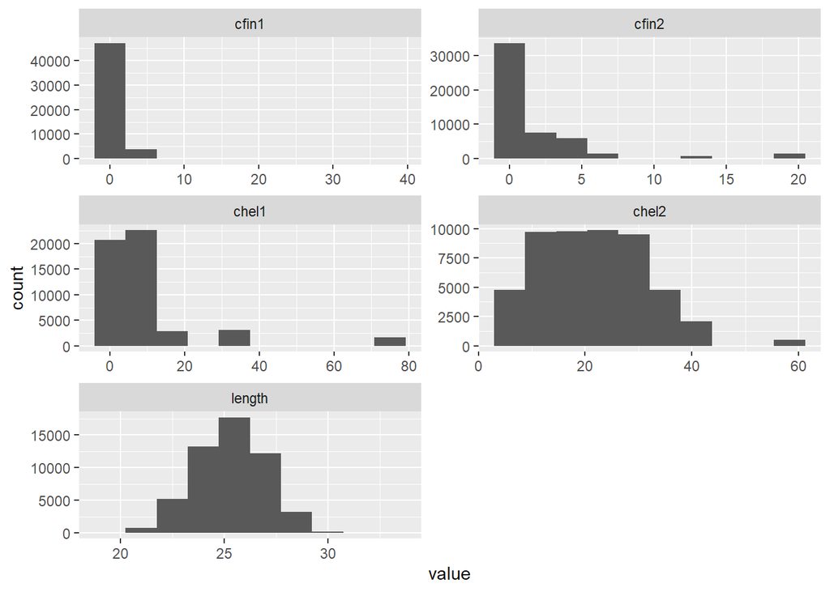

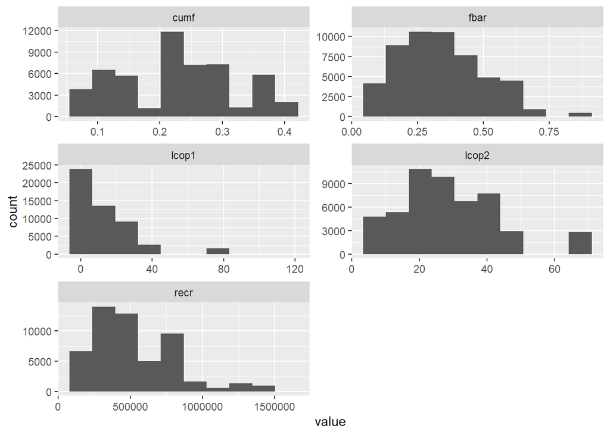

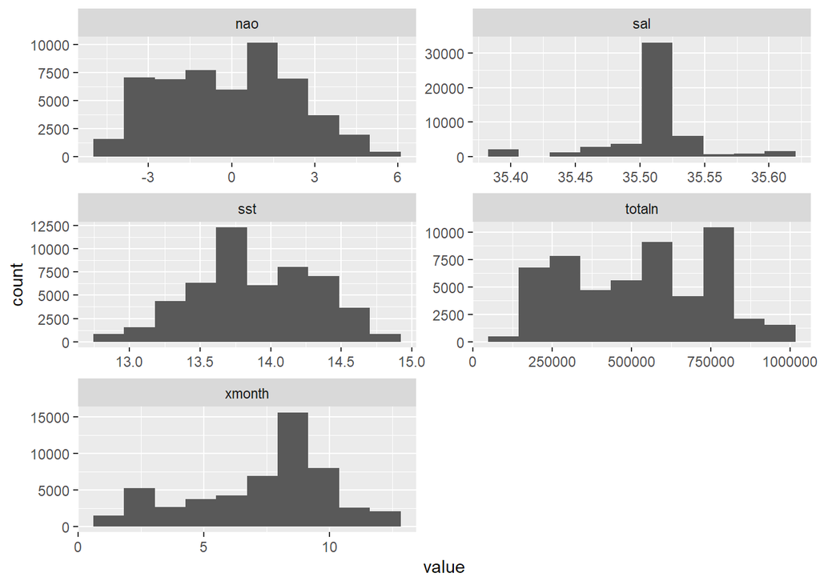

## 7. Korelacja między zmiennymi

Korelację między zmiennymi pokazuje macierz poniżej:

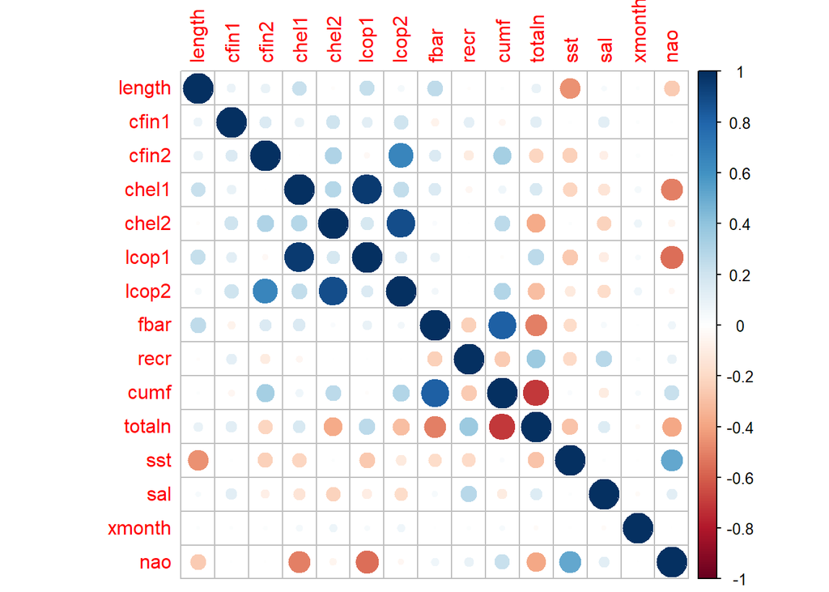

```r
mydata.cor = cor(na.omit(subset(data, select=length:nao)))
corrplot(mydata.cor)
```

## 8. Interaktywny wykres zależności długości śledzia od czasu

```r
xx <- aggregate(length ~ xmonth, data=data, FUN=mean)

f <- list(
  family = "Courier New, monospace",
  size = 18,
  color = "#7f7f7f"
)
x <- list(
  title = "Miesiąc",
  titlefont = f
)
y <- list(
  title = "Długość śledzia [cm]",
  titlefont = f
)

p <- xx %>%
  plot_ly(
    x = ~xmonth,
    y = ~length,
    frame = ~xmonth,
    type = 'scatter',
    mode = 'markers',
    showlegend = F
  ) %>%
  layout(xaxis = x, yaxis = y)
p
```

[interactive chart not shown]

## 9. Regresor przewidujący rozmiar śledzia

Zbiór danych został podzielony w proporcji 60:20:20. Zbiór walidacyjny był używany do optymalizowania parametrów, a zbiór testowy użyty jest teraz do podania ostatecznego wyniku. Do regresji wykorzystano bibliotekę XGBoost.

```r
train_index <- sample(1:nrow(data), 0.6 * nrow(data))
rest_index <- setdiff(1:nrow(data), train_index)
rest <- data[rest_index,]
val_index <- sample(1:nrow(rest), 0.5 * nrow(rest))
test_index <- setdiff(1:nrow(rest), val_index)

X_train <- data[train_index, 3:16]
y_train <- data.frame(data[train_index, 2])

X_val <- data[val_index, 3:16]
y_val <- data.frame(data[val_index, 2])

X_test <- data[test_index, 3:16]
y_test <- data.frame(data[test_index, 2])

dtrain <- xgb.DMatrix(data = as.matrix(X_train),label = as.matrix(y_train))
dval <- xgb.DMatrix(data = as.matrix(X_val),label = as.matrix(y_val))
dtest <- xgb.DMatrix(data = as.matrix(X_test),label = as.matrix(y_test))

params <- list(booster = "gbtree",
               objective = "reg:linear",
               eta=0.2,
               gamma=0.01,
               max_depth=12,
               min_child_weight=0.8,
               subsample=1,
               colsample_bytree=1)

res <- xgb.train( params = params, data = dtrain, nrounds = 50, nfold = 5, showsd = T, stratified = T, maximize = F)
```

Wartości R^2 oraz RMSE przy takich ustawieniach wyglądają następująco

```r
xgbpred <- predict (res,dtest)
rsq <- function (x, y) cor(x, y) ^ 2
r_squared <- rsq(y_test, xgbpred)
print(r_squared[1])
```

```
## [1] 0.4595146
```

```r
RMSE <-  function(m, o){sqrt(mean((m - o)^2))}
test_numeric <- data[test_index, 2]
rmse_res <- RMSE(test_numeric, xgbpred)
print(rmse_res)
```

```
## [1] 1.143579
```

## 10. Analiza ważności atrybutów najlepszego znalezionego modelu regresji

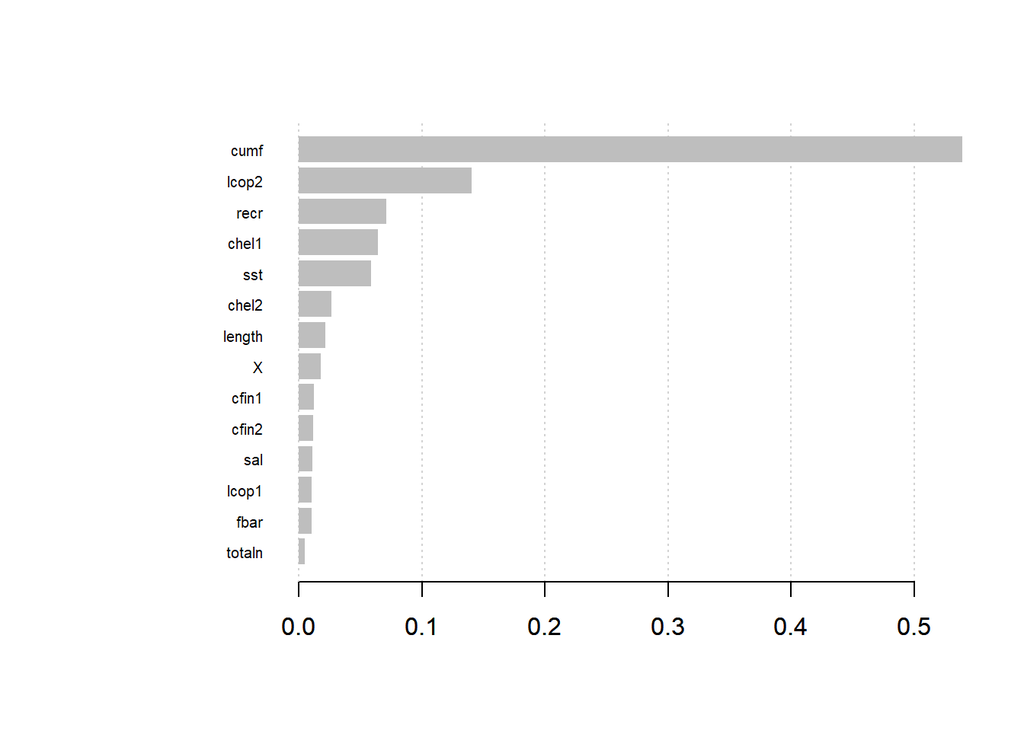

```r
mat <- xgb.importance (feature_names = colnames(data),model = res)
xgb.plot.importance (importance_matrix = mat)
```